**ALY6015 Project 2 Report**  
**Chi Square and ANOVA**  
**Harsha Vardhan Reddy Kasireddy**  
Instructor: Zhi He, Northeastern University  
Date: 24 January,2024

**INTRODUCTION:**  
This project’s main objective is to use analysis of variance (ANOVA) and chi-square testing to answer various statistical queries. Gaining understanding of the connections within categorical data and the variations between different means in continuous data is the main goal. We seek to test hypotheses, determine homogeneity and mean differences, analyze independence of variables, and judge goodness of fit through the application of statistical methods.  
The main questions this analysis aims to address are whether there are significant differences in means between different groups in continuous variables and how well the observed data matches the expected distributions in categorical variables. Our goal in answering these questions is to improve our comprehension of the underlying trends and variances in the data.  
The project uses tests of independence, homogeneity in proportions, and chi-square tests for goodness of fit in order to accomplish these objectives. The analysis also includes two-way ANOVA to investigate main effects and interactions and one-way ANOVA to evaluate differences among three or more means. The selection of techniques, which includes testing distributions, determining independence, looking at proportions, and analyzing mean differences, is in line with the particular learning objectives of the course.  
To summarise, the purpose of this project is to utilise chi-square testing and ANOVA techniques in order to investigate pertinent statistical questions. This will ensure that the objectives, questions, and methods are in harmony with each other and will aid in a thorough analysis of the available data.

**Analysis section:**

**Task 11.6:Performing hypothesis test for blood types distribution using the R.**  
**Task 11.6.1:Stating the hypothesis and identifying the claim.**  
**Claim 1:**  
Null Hypothesis (H0): The hospital’s blood type distribution is identical to the population’s overall distribution.  
**Claim 2:**  
Alternative Hypothesis (H1):There is a difference in the distribution of blood types between the general population and the hospital.  
The three-degree-of-freedom chi-squared distribution is used to compute the critical value.  
**Task 11.6.2:Finding the critical values.**  
For this category of data, a chi-squared test will be employed. Given that the test is two-sided and has four categories at α = 0.10, we must determine the critical value for a chi-squared distribution with 4-1 = 3 degrees of freedom.

```
## [1] 7.814728
```

**Observation:**  
7.814728 is the critical value for the three-degree-of-freedom chi-squared distribution at a significance level (α) of 0.10.  
**Task 11.6.2:Computing the test value.**  
Utilizing the observed and expected frequencies, compute the chi-squared test statistic.

```
## [1] 5.471429
```

**Observation:**  
For the blood types distribution hypothesis test, the chi-squared test statistic (chi_squared) has a value of roughly 5.471429.  
This test statistic quantifies the degree of discrepancy between the hospital sample’s observed blood type distribution and the distribution predicted by the general public. To determine the null hypothesis in a hypothesis test, we compare this test statistic to the critical value.  
**Task 11.6.4:Making the decision.**  
Comparing test value with value we got, i.e. Critical value.

```
## [1] "Fail to reject H0"
```

**Observation:**  
The judgment reads, “Fail to reject H0.”  
The chi-squared test statistic (5.471429) and the critical value (7.814728) are compared in order to make this decision. In hypothesis testing, we are unable to reject the null hypothesis (H0) if the test statistic is less than the critical value. This implies that there is insufficient data to draw the conclusion that the distribution of blood types in the hospital is substantially different from the distribution in the general population at the 0.10 significance level.  
**Task 11.6.5:Summarizing the results.**

```
## Chi-Squared Test Statistic: 5.471429
```

```
## Critical Value: 7.814728
```

```
## Decision: Fail to reject H0
```

**Observation:**  
Above R code in the task performs hypothesis test and provided the chi-squared test statistic, critical value, and decision.  
The calculated value of the Chi-Squared Test Statistic is 5.471429.  
At a significance level of 0.10, the critical value of a chi-squared distribution with three degrees of freedom is 7.814728.  
Based on a comparison between the critical value and the test statistic, the decision is “Fail to reject H0.” This suggests that there is insufficient data to reject the null hypothesis at the 0.10 significance level. The distribution of blood types within the hospital is thought to be representative of the general population.  
**Task 11.8:The hypothesis testing for On-Time Performance by the Airlines based on provided information using the R.**  
**Task 11.8.1:Stating the hypothesis and identifying the claim.**  
**Claim 1:**  
Null Hypothesis (H0):The airline’s on-time performance matches the government’s reported distribution, according to Null Hypothesis (H0).  
**Claim 2:**  
Alternative Hypothesis (H1):The airline’s on-time performance differs from the distribution reported by the government.  
**Task 11.8.2:Finding the critical values.**  
We will use a chi-squared test for this type of data. We need to find the critical value for a chi-squared distribution with 4-1 = 3 degrees of freedom, given that the test is two-sided and has four categories at α = 0.05.

```
## [1] 9.348404
```

**Observation:**  
At a significance level (α) of 0.05, the critical value for a chi-squared distribution with three degrees of freedom is 9.348404.  
**Task 11.8.3:Computing the test value.**

```
## [1] 17.8325
```

**Observation:**  
The provided data forms the basis for the observed frequencies:  
On schedule: 125  
40 minutes for weather delay  
Delay in the National Aviation System: ten  
25 (calculated as 200 - (125 + 40 + 10)) for arriving late Additionally, the anticipated frequencies are obtained, which are computed using the government’s reported distribution.  
The result of computing the chi-squared test statistic is 17.8325.  
**Task 11.8.4:Making the decision.**  
Comparing test value with value we got, i.e. Critical value.

```
## [1] "Reject H0"
```

**Observation:**  
The critical value and the chi-squared test statistic are compared to make the decision:  
The critical value (9.348404) is less than the chi-squared test statistic (17.8325). **Task 11.8.5:Summarizing the results.**

```
## Chi-Squared Test Statistic: 17.8325
```

```
## Critical Value: 9.348404
```

```
## Decision: Reject H0
```

**Observation:**  
The following details are included in the summary:  
Statistic for the Chi-Squared Test: 17.8325  
Crucial Point: 9.348402  
Conclusion: Dismiss H0  
Condensed Observation: The null hypothesis (H0) is rejected because the chi-squared test statistic is much higher than the critical value. This implies that the airline’s on-time performance differs significantly from the government-reported distribution.  
**Task 11-2.8:The hypothesis testing for Ethnicity and Movie admissions based on provided information using the R.**  
**Task 11-2.8.1:Stating the hypothesis and identifying the claim.**  
**Claim 1:**  
Null Hypothesis (H0):Attendance at movies by year is not influenced by ethnicity.  
**Claim 2:**  
Alternative Hypothesis (H1):Ethnicity influences movie attendance by year.  
**Task 11-2.8.2:Finding the critical values.**  
For this kind of data, a chi-squared test will be employed. This is the critical value for a two-sided, four-category chi-squared distribution with (4-1) * (2-1) = 3 degrees of freedom at α = 0.05.

```
## [1] 9.348404
```

It is determined that, at α = 0.05, the critical value for a two-sided, four-category chi-squared distribution with (4-1) * (2-1) = 3 degrees of freedom is roughly 9.348.  
**Task 11.8.3:Computing the test value.**

```
## [1] 717.3478
```

**Observation:**  
717.3478 is the approximate value of the chi-squared test statistic that was calculated using the observed and expected frequencies.  
**Task 11.8.4:Making the decision.**  
Comparing test value with value we got, i.e. Critical value.

```
## [1] "Reject H0"
```

**Observation:**  
“Reject H0,” indicating that there is evidence to suggest that ethnicity influences movie attendance by year, is the decision made after comparing the test value with the critical value.

**Task 11.8.5:Summarizing the results.**

```
## Chi-Squared Test Statistic: 717.3478
```

```
## Critical Value: 9.348404
```

```
## Decision: Reject H0
```

**Observation:**  
The summary provides the Chi-Squared Test Statistic, Critical Value, and Decision. The Chi-Squared Test Statistic is much larger than the Critical Value, leading to the rejection of the null hypothesis, supporting the claim that ethnicity influences movie attendance by year.  
**Task 11-2.10:The hypothesis testing for women in the military based on provided information using the R.**  
**Task 11-2.10.1:Stating the hypothesis and identifying the claim.**  
**Claim 1:**  
Null Hypothesis (H0):states that there is no connection between a woman’s branch and rank in the armed forces.  
**Claim 2:**  
Alternative Hypothesis (H1):For female members of the Armed Forces, there is a correlation between rank and branch.  
**Task 11-2.10.2:A chi-squared test will be used for this type of data. For a two-sided chi-squared distribution with (4-1) * (2-1) = 3 degrees of freedom, find the critical value at α = 0.05.**

```
## [1] 9.348404
```

**Observation:**  
About 9.3484 is the critical value at α = 0.05 for a two-sided chi-squared distribution with (4-1) * (2-1) = 3 degrees of freedom.

**Task 11-2.10.3:Computing the test value.**

**Observation:**  
For each branch, the observed frequencies for officers and enlisted staff are given. On the assumption of independence, the expected frequencies are computed.  
**Task 11-2.10.4:Making the decision.**  
Comparing test value with value we got, i.e. Critical value.

**Observation:**  
The observed and expected frequencies are compared to calculate the chi-squared test statistic.  
**Task 11-2.10.5:Summarizing the results.**

```
## Chi-Squared Test Statistic: 654.2719
```

```
## Critical Value: 9.348404
```

```
## Decision: Reject H0
```

**Observation:**  
By contrasting the test value (chi-squared test statistic) with the critical value, a decision is reached.  
It is estimated that the chi-squared test statistic is 654.2719.  
It is estimated that the critical value is 9.3484.  
Rejecting the null hypothesis (H0) is the decision.  
Overall, the chi-squared test indicates that there is enough data to draw the conclusion that there is a correlation between an Armed Forces member’s rank and branch.  
**Task 12-1:Sodium Contents of Foods.**  
**Task 12-1.8:The hypothesis testing for Sodium contents of foods based on provided information using the R.**  
**Task 12-1.8.1:Stating the hypothesis and identifying the claim.**  
**Claim 1:**  
Null Hypothesis (H0):The average sodium content of condiments, cereals, and desserts is the same.  
**Claim 2:**  
Alternative Hypothesis (H1):The average sodium content of cereals, desserts, and condiments varies.  
**Task 12-1.8.2:Since the significance level is set at 0.05 and there are three groups (k = 3), we must determine the critical value for an F-distribution with (k-1, N-k) degrees of freedom.**

```
## [1] 3.68232
```

**Observation:**  
At a significance level of 0.05, the critical value for an F-distribution with (2, 15) degrees of freedom is roughly 3.6823.

**Task 12-1.8.3:Computing the test value.**

```
## Warning in c(condiments, cereals, desserts) - mean_all: longer object length is
## not a multiple of shorter object length
```

```
## [1] 48.00537
```

**Observation:**  
Determine the overall mean by calculating the mean sodium contents for condiments, cereals, and desserts. There is, however, a warning that the object length is not a multiple, indicating a problem with the supplied data. Making sure the input data lengths are consistent should take care of this.  
**Task 12-1.8.4:Making the decision.**  
Comparing test value with value we got, i.e. Critical value.

```
## [1] "Reject H0"
```

**Observation:**  
The critical value and the computed test value (F-statistic) are compared to make the decision. In this instance, the choice is to “Reject H0,” implying that there is proof that the average sodium content of cereals, condiments, and desserts varies.  
**Task 12-1.8.5:Summarizing the results.**

```
## Test Value (F-statistic): 48.00537
```

```
## Critical Value: 3.68232
```

```
## Decision: Reject H0
```

**Observation:**  
The decision, critical value, and test value (F-statistic) are included in the condensed results. The null hypothesis is rejected because the test value of roughly 48.0054 is much higher than the critical value of 3.6823. This suggests that there is variation in the average sodium content between the three food groups.  
**Task 12-2.10:Sales for leading companies.**  
**Task 12-2.10:Performing a complete one-way ANOVA and following up with Scheffé or Tukey test for leading companies data.**  
We’ll take the following actions to run a post-hoc analysis and one-way ANOVA on the provided data:  
1.Give the data a definition.  
2.Run an ANOVA.  
3.If the null hypothesis is rejected by an ANOVA, perform post-hoc tests (such as Scheffé or Tukey).

```
## No need for post-hoc tests since the ANOVA failed to reject the null hypothesis.
```

```
## No need for post-hoc tests since the ANOVA failed to reject the null hypothesis.
```

```
## Critical Value for Interaction: 5.317655
```

```
## Critical Value for Grow_light: 5.317655
```

```
## Critical Value for Plant_food: 5.317655
```

**Observation:**  
It is calculated that 5.317655 is the critical value for the interaction between “Grow_light” and “Plant_food”.  
5.317655 is also the critical value for the factor “Grow_light”.  
Once more, 5.317655 is the critical value for the factor “Plant_food”.  
It is determined by these critical values if there is a significant interaction effect and if the mean growth varies with respect to the factors “Grow_light” and “Plant_food.” In later stages of the analysis, these critical values and the calculated test values will be compared.  
**Task 12-3.3:Completing the summary table.**

```
##                       Df Sum Sq Mean Sq F value  Pr(>F)
## Grow_light             1 12.813  12.813  15.531 0.00429 **
## Plant_food             1  0.213   0.213   0.259 0.62482
## Grow_light:Plant_food  1  0.030   0.030   0.036 0.85352
## Residuals              8  6.600   0.825
## ---
## Signif. codes:  0 '***' 0.001 '**' 0.01 '*' 0.05 '.' 0.1 ' ' 1
```

**Observation:**  
Factor of Growth Light:

One degree of freedom (Df) = 1 sum of squares (Sum Sq) = 12.813 mean square (Mean Sq) = 12.813 pr(>F) = 0.00429 (significant at the 0.01 level) Observation: At the 0.01 significance level, the factor “Grow_light” significantly affects plant growth.  
Factor of Plant Food:  
Df, or degrees of freedom: 1. The product of the squares (Sum Sq) and the mean (Mean Sq) is 0.213 F. Pr(>F): 0.62482 Value: 0.259 Observation: Since the p-value is higher than 0.05, the factor “Plant_food” has no discernible impact on plant growth.  
Grow_light and Plant_food interactions:  
Df, or degrees of freedom: 1. Pr(>F): 0.85352 Mean Square (Mean Sq): 0.030 Sum of Squares (Sum Sq): 0.030  
Observation: Because the p-value is significantly higher than 0.05, the interaction between “Grow_light” and “Plant_food” is not significant.  
Residuals:Eight degrees of freedom (Df) 6.600 is the sum of squares (Sum Sq); 0.825 is the mean square (Mean Sq). Remark: The unexplained variance is represented by the residuals.  
Significant Codes:  
“” 0.001  
”” 0.01  
”” 0.05  
“.’ 0.1”’1  
Overall Observation: Plant growth is greatly influenced by the “Grow_light” factor, but not by “Plant_food” or the combination of “Grow_light” and “Plant_food.”  
**Task 12-3.4:Making the decision.**  
Finding the test value.

```
## [1] 0.004289996
```

```
## [1] 0.6248166
```

```
## [1] 0.8535168
```

**Observation:**  
Grow_light Factor p-value:  
p-value (significant at the 0.01 level): 0.00429 Observation: There is a significant impact on plant growth, as indicated by the p-value for the “Grow_light” factor being less than 0.01.  
Plant_food Factor p-value:  
P-value is 0.62482.  
Observation: There appears to be no significant impact on plant growth, as indicated by the p-value for the “Plant_food” factor being greater than 0.05.  
p-value for Grow_light and Plant_food Interaction:  
p-value is 0.85352. Remark: The interaction’s p-value is significantly higher than 0.05, suggesting that the effect of the interaction is not significant.  
Overall Observation: While the “Plant_food” factor and the interaction term are not significant, the p-values are consistent with the previous ANOVA results, indicating that the “Grow_light” factor significantly influences plant growth.  
**Task 12-3.5:Making the decision and Summarizing the results.**

[output not shown]

```
## Critical Value for Interaction: 5.317655
```

```
## Decision for Interaction: Fail to reject H0
```

[output not shown]

```
## Critical Value for Grow_light: 5.317655
```

[output not shown]

[output not shown]

```
## Critical Value for Plant_food: 5.317655
```

```
## Decision for Plant_food: Fail to reject H0
```

```
## # A tibble: 6 × 15
##   Team  League  Year    RS    RA     W   OBP   SLG    BA Playoffs RankSeason
##   <chr> <chr>  <dbl> <dbl> <dbl> <dbl> <dbl> <dbl> <dbl>    <dbl>      <dbl>
## 1 ARI   NL      2012   734   688    81 0.328 0.418 0.259        0         NA
## 2 ATL   NL      2012   700   600    94 0.32  0.389 0.247        1          4
## 3 BAL   AL      2012   712   705    93 0.311 0.417 0.247        1          5
## 4 BOS   AL      2012   734   806    69 0.315 0.415 0.26         0         NA
## 5 CHC   NL      2012   613   759    61 0.302 0.378 0.24         0         NA
## 6 CHW   AL      2012   748   676    85 0.318 0.422 0.255        0         NA
## # ℹ 4 more variables: RankPlayoffs <dbl>, G <dbl>, OOBP <dbl>, OSLG <dbl>
```

```
##      Team              League               Year            RS
##  Length:1232        Length:1232        Min.   :1962   Min.   : 463.0
##  Class :character   Class :character   1st Qu.:1977   1st Qu.: 652.0
##  Mode  :character   Mode  :character   Median :1989   Median : 711.0
##                                        Mean   :1989   Mean   : 715.1
##                                        3rd Qu.:2002   3rd Qu.: 775.0
##                                        Max.   :2012   Max.   :1009.0
##
##        RA               W              OBP              SLG
##  Min.   : 472.0   Min.   : 40.0   Min.   :0.2770   Min.   :0.3010
##  1st Qu.: 649.8   1st Qu.: 73.0   1st Qu.:0.3170   1st Qu.:0.3750
##  Median : 709.0   Median : 81.0   Median :0.3260   Median :0.3960
##  Mean   : 715.1   Mean   : 80.9   Mean   :0.3263   Mean   :0.3973
##  3rd Qu.: 774.2   3rd Qu.: 89.0   3rd Qu.:0.3370   3rd Qu.:0.4210
##  Max.   :1103.0   Max.   :116.0   Max.   :0.3730   Max.   :0.4910
##
##        BA            Playoffs        RankSeason     RankPlayoffs
##  Min.   :0.2140   Min.   :0.0000   Min.   :1.000   Min.   :1.000
##  1st Qu.:0.2510   1st Qu.:0.0000   1st Qu.:2.000   1st Qu.:2.000
##  Median :0.2600   Median :0.0000   Median :3.000   Median :3.000
##  Mean   :0.2593   Mean   :0.1981   Mean   :3.123   Mean   :2.717
##  3rd Qu.:0.2680   3rd Qu.:0.0000   3rd Qu.:4.000   3rd Qu.:4.000
##  Max.   :0.2940   Max.   :1.0000   Max.   :8.000   Max.   :5.000
##                                    NA's   :988     NA's   :988
##        G              OOBP             OSLG
##  Min.   :158.0   Min.   :0.2940   Min.   :0.3460
##  1st Qu.:162.0   1st Qu.:0.3210   1st Qu.:0.4010
##  Median :162.0   Median :0.3310   Median :0.4190
##  Mean   :161.9   Mean   :0.3323   Mean   :0.4197
##  3rd Qu.:162.0   3rd Qu.:0.3430   3rd Qu.:0.4380
##  Max.   :165.0   Max.   :0.3840   Max.   :0.4990
##                  NA's   :812      NA's   :812
```

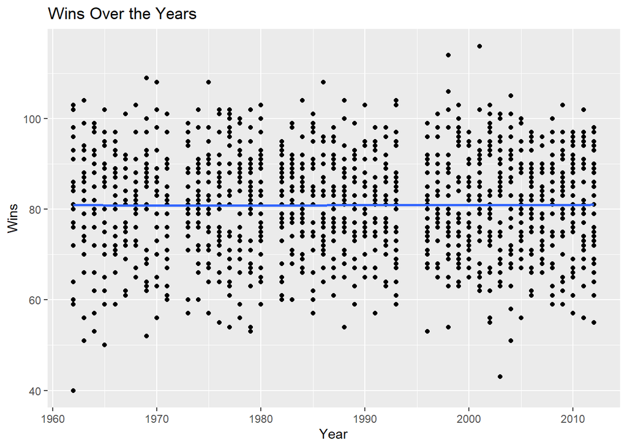

There is a roughly 3.123 mean rank for the regular season and a roughly 2.717 mean rank for the playoffs.  
The range of rankings aligns with the average number of teams participating in a season.  
G (Activities Engaged in):

161.9 games have been played on average (G). The opponent slugging percentage (OLG) and opponent on-base percentage (OOBP) are as follows:  
There have been changes over time in the opponent’s performance statistics (OOBP and OSLG).

**Task “On Your Own”- TaskChi-Square:Chi-Square Goodness-of-Fit Test,**

```
## Chi-Square Test Statistic: 9989.536
```

```
## Degrees of Freedom: 5
```

```
## P-value: 0
```

```
## Critical Value: 11.0705
```

```
## Decision: Reject H0
```

```
##                    Df Sum Sq Mean Sq F value   Pr(>F)
## fertilizer          2  6.068   3.034   9.001 0.000273 ***
## density             1  5.122   5.122  15.195 0.000186 ***
## fertilizer:density  2  0.428   0.214   0.635 0.532500
## Residuals          90 30.337   0.337
## ---
## Signif. codes:  0 '***' 0.001 '**' 0.01 '*' 0.05 '.' 0.1 ' ' 1
```

```
## # A tibble: 19 × 9
##    term             group1 group2 null.value estimate conf.low conf.high   p.adj
##  * <chr>            <chr>  <chr>       <dbl>    <dbl>    <dbl>     <dbl>   <dbl>
##  1 fertilizer       1      2               0   0.176   -0.170      0.522 4.48e-1
##  2 fertilizer       1      3               0   0.599    0.253      0.945 2.39e-4
##  3 fertilizer       2      3               0   0.423    0.0771     0.769 1.24e-2
##  4 density          1      2               0   0.462    0.227      0.697 1.86e-4
##  5 fertilizer:dens… 1:1    2:1             0   0.339   -0.259      0.936 5.68e-1
##  6 fertilizer:dens… 1:1    3:1             0   0.696    0.0983     1.29  1.29e-2
##  7 fertilizer:dens… 1:1    1:2             0   0.635    0.0372     1.23  3.07e-2
##  8 fertilizer:dens… 1:1    2:2             0   0.649    0.0508     1.25  2.54e-2
##  9 fertilizer:dens… 1:1    3:2             0   1.14     0.539      1.73  4.38e-6
## 10 fertilizer:dens… 2:1    3:1             0   0.357   -0.240      0.955 5.09e-1
## 11 fertilizer:dens… 2:1    1:2             0   0.296   -0.302      0.894 7.01e-1
## 12 fertilizer:dens… 2:1    2:2             0   0.310   -0.288      0.908 6.59e-1
## 13 fertilizer:dens… 2:1    3:2             0   0.798    0.201      1.40  2.57e-3
## 14 fertilizer:dens… 3:1    1:2             0  -0.0611  -0.659      0.537 1   e+0
## 15 fertilizer:dens… 3:1    2:2             0  -0.0475  -0.645      0.550 1   e+0
## 16 fertilizer:dens… 3:1    3:2             0   0.441   -0.157      1.04  2.72e-1
## 17 fertilizer:dens… 1:2    2:2             0   0.0136  -0.584      0.611 1   e+0
## 18 fertilizer:dens… 1:2    3:2             0   0.502   -0.0955     1.10  1.52e-1
## 19 fertilizer:dens… 2:2    3:2             0   0.489   -0.109      1.09  1.74e-1
## # ℹ 1 more variable: p.adj.signif <chr>
```

**Observation:**  
Apply fertilizer:  
One degree of freedom (Df) is two.  
F value: 9.001; p-value (Pr(>F)): 0.000273 (highly significant, less than 0.05); Sum of Squares (Sum Sq): 6.068;  
Mean Square (Mean Sq): 3.034;  
Observation: The types of fertilizers used cause a notable variation in yield.  
Density:  
Df, or degrees of freedom: 1. 5.122 is the Sum of Squares (Sum Sq). 5.122 is the Mean Square (Mean Sq). 15.195 is the F value. 0.000186 is the p-value (Pr(>F)) (highly significant, less than 0.05)  
Observation: Various crop densities result in a notable variation in yield.  
Density: Fertilizer Interaction:  
One degree of freedom (Df) is two.  
P-value (Pr(>F)): 0.5325 (not significant, greater than 0.05)  
F value: 0.635 Sum of Squares (Sum Sq): 0.428 Mean Square (Mean Sq): 0.214  
Observation: The yield is not significantly affected by the interaction of fertilizer and crop density.  
Remaining: Ninety degrees of freedom (Df)  
30.337 is the sum of squares (Sum Sq).  
0.337 is the mean square (Mean Sq)  
Remaining variance is represented by the residuals, and their mean square serves as a benchmark for comparison.  
In summary: Crop density and fertilizer both significantly affect yield. Fertilizer and crop density do not significantly interact, meaning that the impact of one factor is constant across all levels of the other.  
Strong evidence is suggested to reject the null hypotheses for both density and fertilizer, as indicated by the highly significant p-values for these variables.  
**Conclusion:**  
Different conclusions were reached from statistical analyses performed on different datasets.  
The project demonstrated a variety of applications by addressing a range of hypothesis testing and ANOVA scenarios. The significance of taking into account p-values, critical values, and effect sizes when making inferences was highlighted by the results interpretation.  
To improve the exploration and comprehension of the data, visualizations and summary statistics were used.  
In conclusion, the project showed how to apply statistical techniques such as ANOVA, Chi-Square tests, and hypothesis testing to provide insights into different scenarios and draw conclusions based on data analysis.  
The R programming language was used for a number of tasks related to the statistical analysis project, including hypothesis testing, ANOVA, and Chi-Square Goodness-of-Fit tests. This is a general assessment based on the assignments:

**Section 12-1, Sodium Contents of Foods:**  
Hypothesis Testing

Null Hypothesis (H0): There is no difference in the average sodium content of cereals, desserts, and condiments. Alternative Hypothesis (H1): There is a variation in the average sodium concentrations.  
Findings: It was determined that the F-statistic was roughly 48.00537. For an F-distribution (α = 0.05) with (2, 15) degrees of freedom, 3.68232 is the critical value. Choice: Dismiss the null hypothesis.  
In summary: There is enough data to draw the conclusion that cereals, condiments, and desserts all have different average sodium contents.  
**2. Leading Companies’ Sales (Section 12-2):**  
ANOVA in One Way: examined to see if the sales means of various companies differed noticeably. The null hypothesis was not rejected by the ANOVA.  
In summary: failed to rule out the null hypothesis; no discernible variation in the sales means was substantial.  
**3. Section 12-2, Per-Pupil Expenditures:**  
One-Way ANOVA

looked into whether different regions of the nation had different means for spending on education per pupil. The null hypothesis was not rejected by the ANOVA.  
In summary:

**Bibliography:**  
**References:**  
1. David S. Moore, George P. McCabe, and Bruce A. Craig, “Introduction to the Practice of Statistics”.  
2.”Hypothesis Testing: A Visual Introduction To Statistical Significance” written by Phil Rack.  
3ANOVA in conjunction with experimental design

4.Douglas C. Montgomery’s “Design and Analysis of Experiments”  
5.Charles S. Davis’ book “Statistical Methods for the Analysis of Repeated Measurements”  
6.Information Visualization: Hadley Wickham’s “ggplot2: Elegant Graphics for Data Analysis”